# IE 360 HW 1

## 1) Introduction

I wanted to investigate the effect of money supply increase on food prices and the effect of increase in food prices on the volume of foreign currencies at the bank depoists. My hyptohesis is Increase in the money supply improve the consumption demand, increase in the conumptions demand increase the price of goods and services (infliation). Inflation causes the lower the value of national currency against foreign currency, economic units hold foreign currency deposit in order to protect their purchasing power. So, volume of foreign currency depists should be rising with such trend of monney supply. I have gathered monney supply(m2), food prices index and foreign currency deposits in order to investigate my assumption. I also took the " kira artışı" search volumes by google trends, I think that is also highly corralated with the price index.

## 2) Trends & Boxplots & Historgrams of the Investigated Data

Downloading reqired libraries.

Reading the data for further implementations.

```r
money_supply <- read_excel('C:/Users/OZAN/Documents/360 hw 1 datas/money supply.xlsx')
foreign_currency <- read_excel('C:/Users/OZAN/Documents/360 hw 1 datas/foreign currency.xlsx')
food_price <- read_excel('C:/Users/OZAN/Documents/360 hw 1 datas/food prices.xlsx')
google_data <- read_excel('C:/Users/OZAN/Documents/360 hw 1 datas/google_data.xlsx')

money_supply$Date <- as.yearmon(money_supply$Date)
foreign_currency$Date <- as.yearmon(foreign_currency$Date)
food_price$Date <- as.yearmon(food_price$Date)
google_data$Date <- as.yearmon(google_data$Date)


head(money_supply,25)
```

```
## # A tibble: 25 x 2
##    Date      Money_Supply
##    <yearmon>        <dbl>
##  1 Oca 2019   1042886601.
##  2 Şub 2019   1071369695.
##  3 Mar 2019   1188087118.
##  4 Nis 2019   1249180758.
##  5 May 2019   1270562517.
##  6 Haz 2019   1244901230.
##  7 Tem 2019   1243546974.
##  8 Ağu 2019   1274973384.
##  9 Eyl 2019   1272515753.
## 10 Eki 2019   1296086723.
## # ... with 15 more rows
```

```r
str(money_supply)
```

```
## tibble [36 x 2] (S3: tbl_df/tbl/data.frame)
##  $ Date        : 'yearmon' num [1:36] Oca 2019 Şub 2019 Mar 2019 Nis 2019 ...
##  $ Money_Supply: num [1:36] 1.04e+09 1.07e+09 1.19e+09 1.25e+09 1.27e+09 ...
```

### 2.1) Money Supply

Money supply emissioned in order to satisfy the markets demand by central bank. Markets demand naturally grows over time but also if the money supply exceed productions rate it will result inflation.

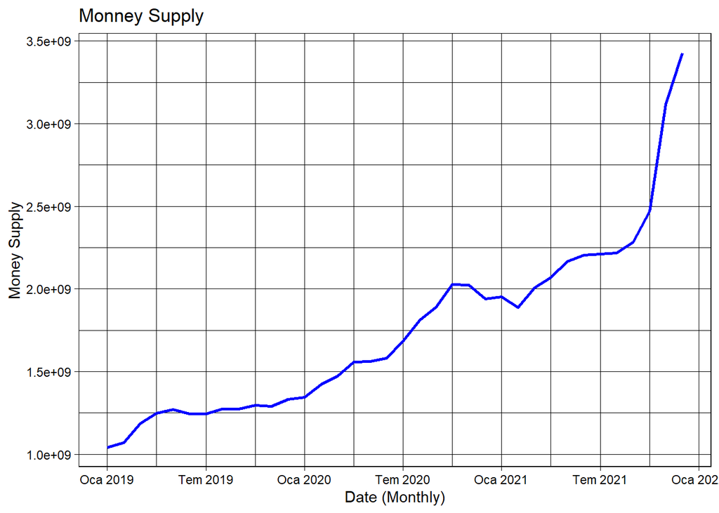

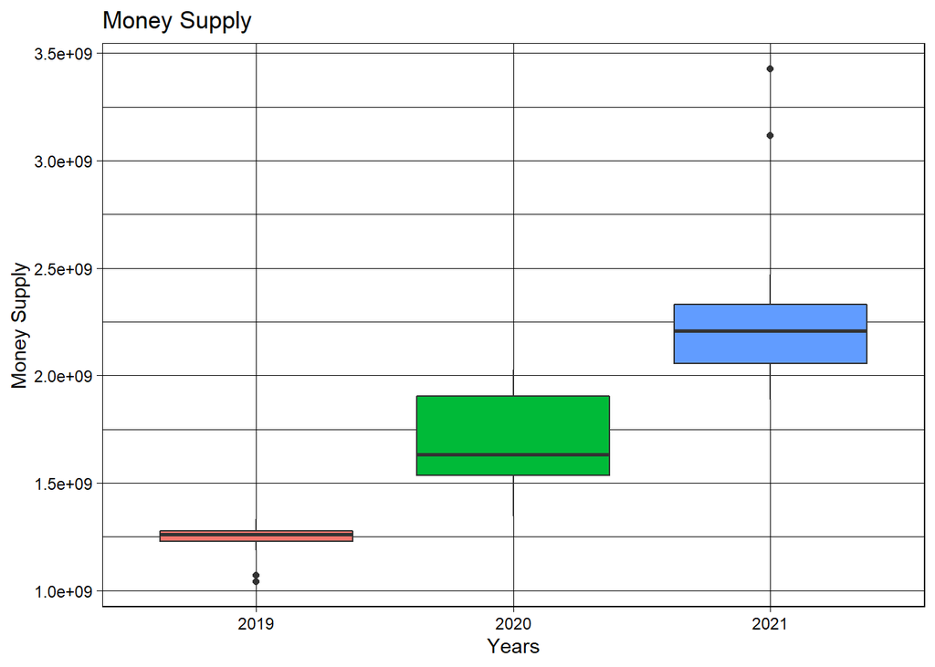

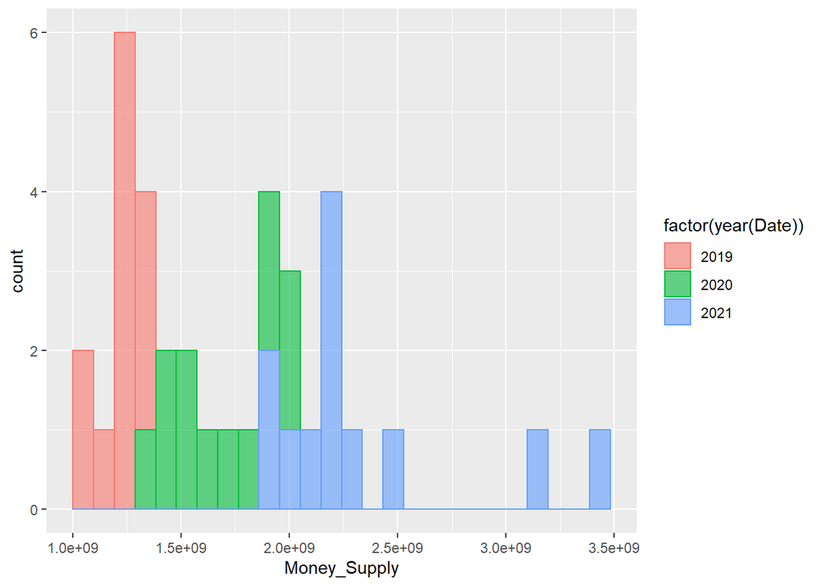

```r
ggplot(money_supply, aes(x=factor(year(Date)),y=Money_Supply)) +
geom_boxplot(aes(fill=factor(year(Date)))) +
xlab("Years") + ylab("Money Supply") +
ggtitle("Money Supply") +
theme_linedraw() + theme(legend.position = "none")
```

### 2.3) Food Prices

Food prices is one of important the sub-ındex of customer price index.

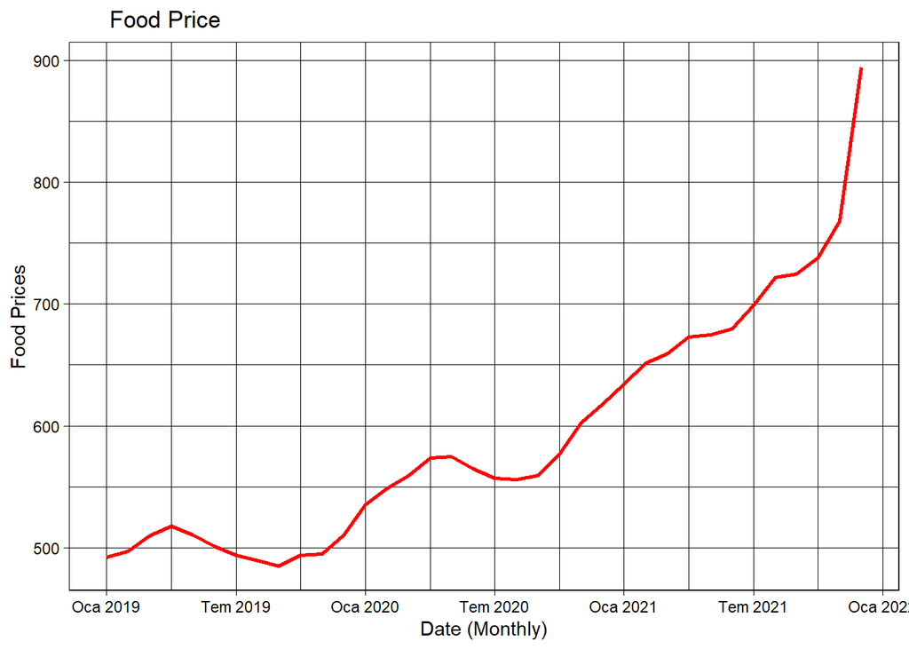

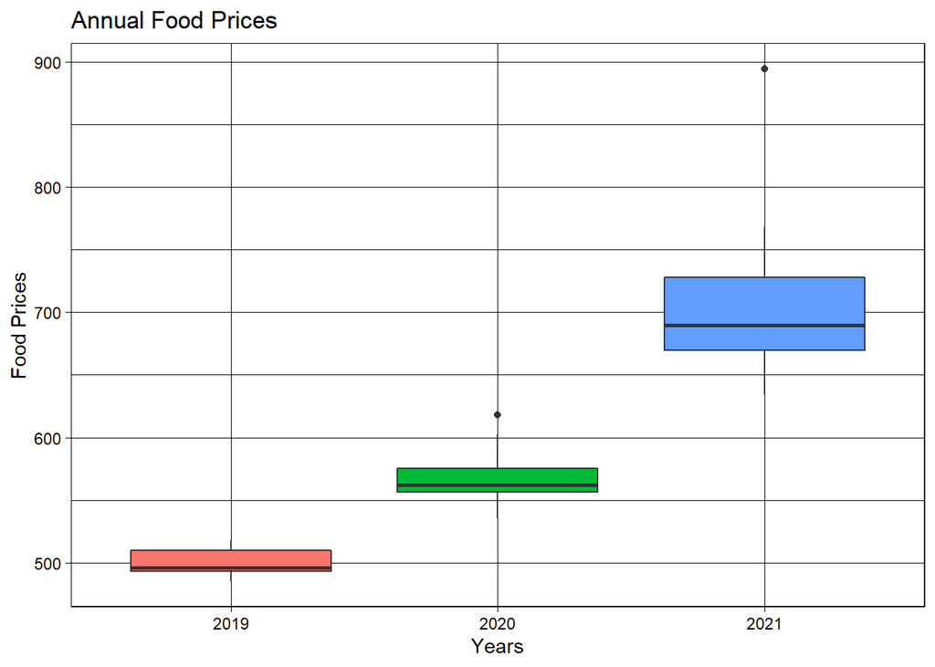

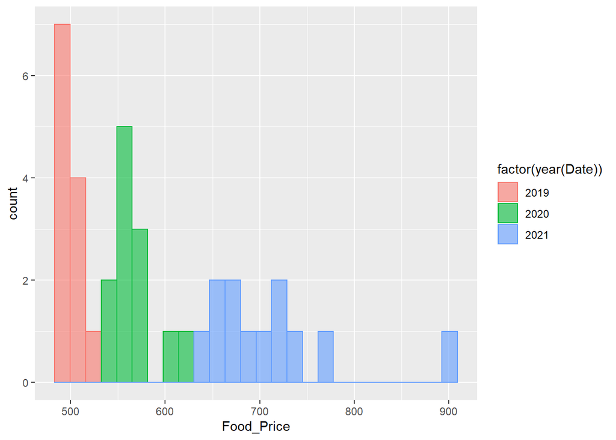

### 2.3) Foreign Currency Depoists

Increase in the foreign currency deposits is one of the indicator of currency substitution.

[figure not shown]

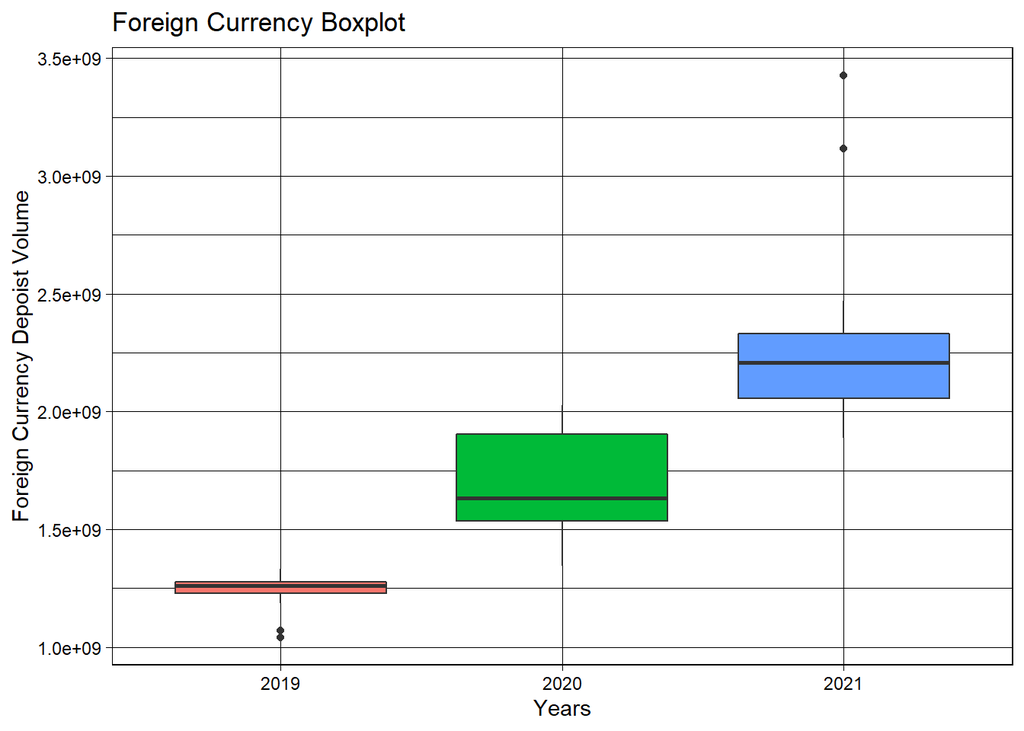

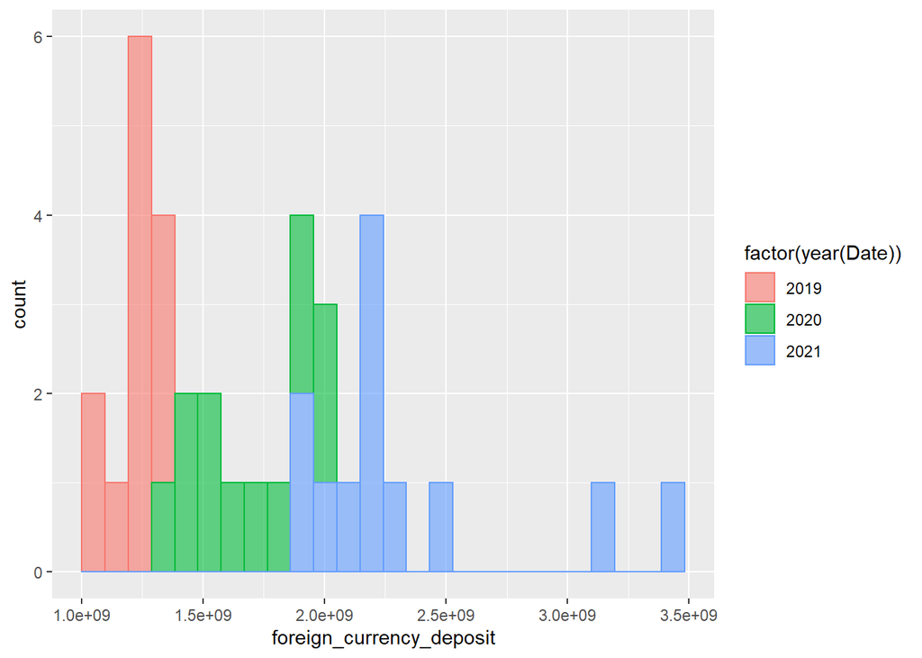

[figure not shown]

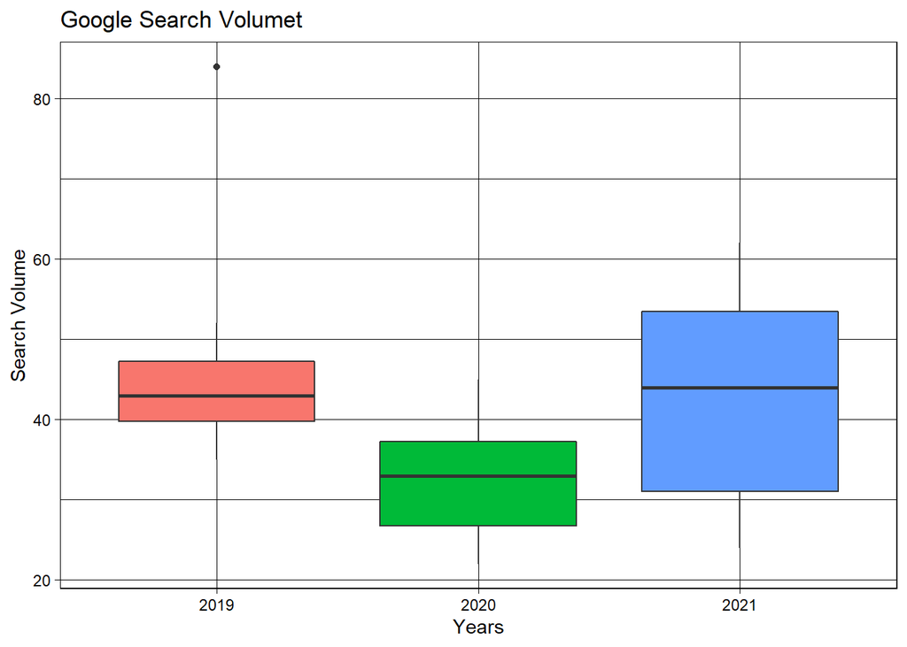

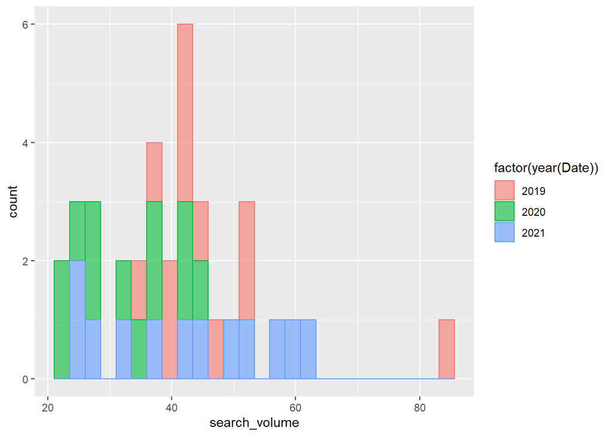

```r
ggplot(google_data, aes(search_volume))+geom_histogram(alpha=0.6,bins=26,aes(fill=factor(year(Date)), color=factor(year(Date))))
```

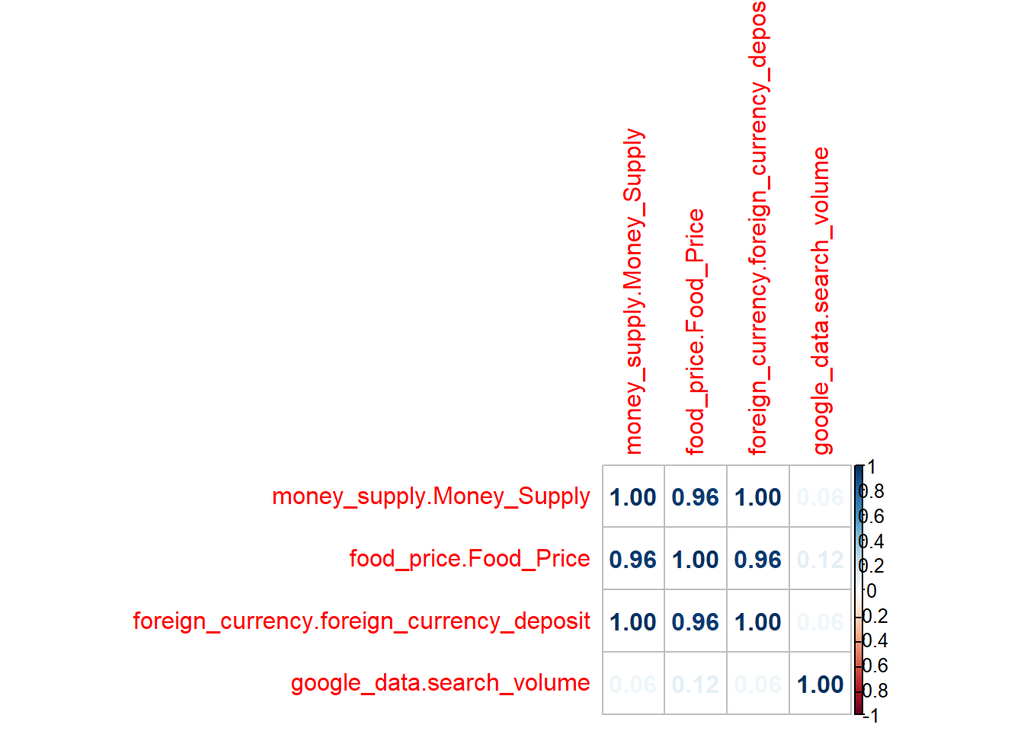

```r
sumdata <- data.frame( money_supply$Money_Supply,  food_price$Food_Price, foreign_currency$foreign_currency_deposit, google_data$search_volume)

data_cor = cor(sumdata)
corrplot(data_cor, method="number")
```

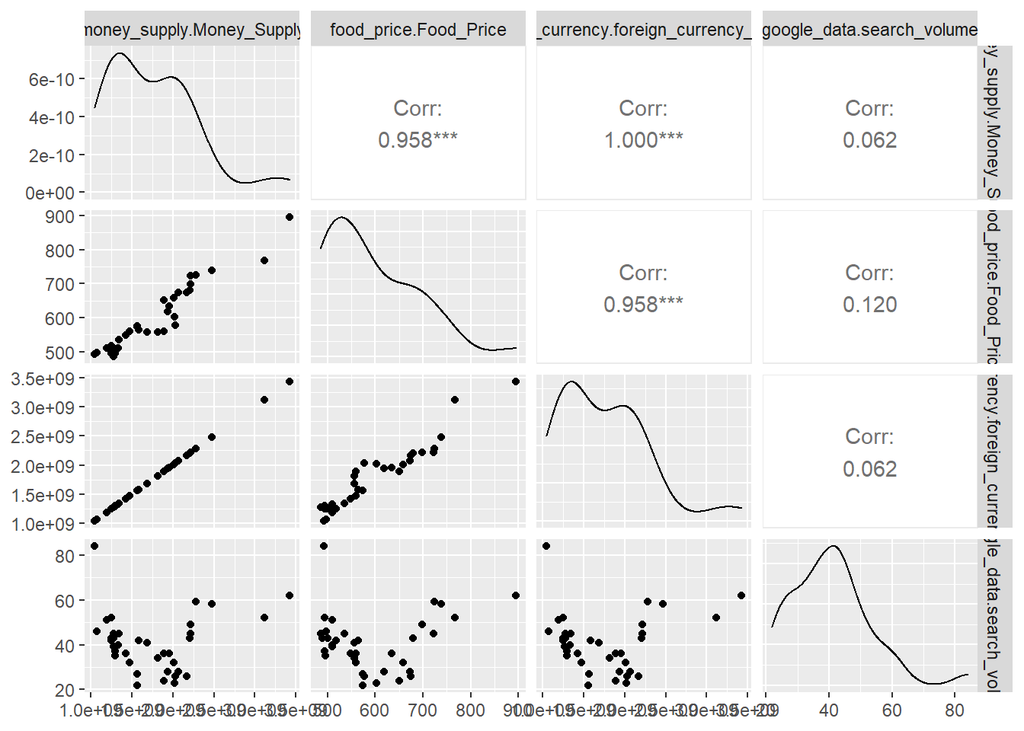

```r
ggpairs(sumdata)
```

## 3) Conclusion This corralation values shows that all food price index, money supply and foreign currency bank deposits strongly corralated with each other. Desptite these statistical analysis, economic view of the story also proves the strong relationship between these topics. However, there is no significant relation with the search term “kira artışı” with the corraleted datas from EVDS. Annual announcments of the customer price index and renting contracts could be the reasons fot the weak corralation.